# Informe de sensor

Ureña, I. y Bolívar, H.

21 noviembre, 2021

### Datos del sensor

Nombre del sensor: Prueba anual

Número de serie: SN 40807936

Fecha de inicio de toma de datos: 14/11/2018 08:44:11

Fecha de fin de la toma de datos: 16/01/2020 10:44:11

Número total de datos tomados: 10273

Número de errores de datos de temperatura: 0

Número de errores de datos de humedad relativa: 0

Los datos se descargaron el día 23/01/2020 16:18:16

### Análisis global de las variables

#### Tabla resumen:

Tabla Análisis Global Temperatura (ºC) y Humedad Relativa (%)

| Variable | n | Media | SD | Min | Max | OA | se | P0.023 | P0.5 | P0.977 |
| --- | --- | --- | --- | --- | --- | --- | --- | --- | --- | --- |
| T ºC global | 10273 | 19.1 | 6.7 | 4.0 | 46.9 | 42.9 | 0.1 | 8.2 | 17.9 | 32.9 |
| %HR global | 10273 | 69.7 | 13.5 | 16.1 | 99.9 | 83.8 | 0.1 | 39.7 | 71.2 | 92.3 |

SD = Desviación típica  
OA = Oscilación absoluta  
se = Error estándar  
P = Percentiles  
El 95% de los datos se encuentra entre el percentil 0.023 y el 0.977

#### Evolución temporal de las variables

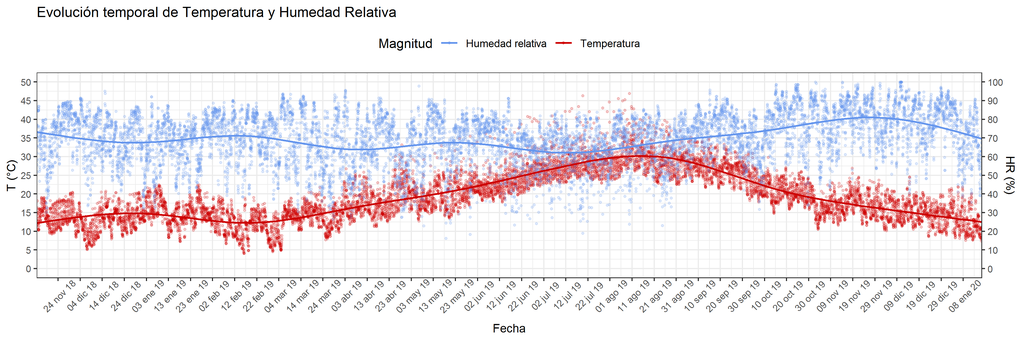

#### Histogramas y diagramas de caja de las variables

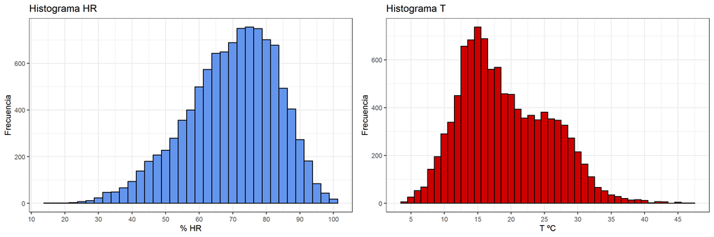

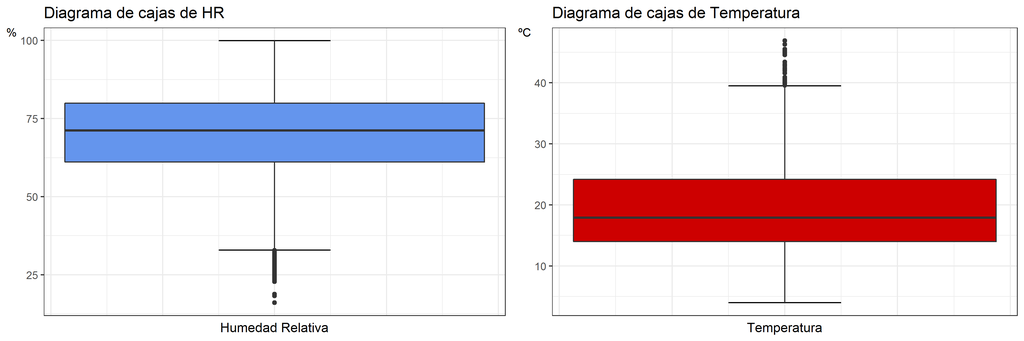

#### Oscilaciones globales

##### Oscilación máxima diaria

Máxima oscilación diaria para la Humedad relativa: 74.4% el día 18/05/2019.

Máxima oscilación diaria para la Temperatura: 21.3ºC el día 04/08/2019.

##### Oscilación máxima horaria

Máxima oscilación horaria para la Humedad relativa: 42.3% el día 06/05/2019 13 horas.

Máxima oscilación horaria para la Temperatura: 14.3ºC el día 04/08/2019 19 horas.

##### Diagramas de caja de los valores absolutos de las oscilaciones diarias y horarias

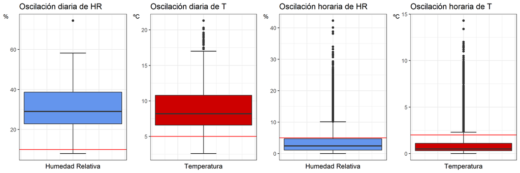

### Análisis anual de las variables

#### Tabla resumen:

Tabla Análisis Anual Temperatura (ºC) y Humedad Relativa (%)

| Año | n() | Nº Días | Media HR | Mediana HR | SD HR | Min HR | Max HR | OAA HR | Media T | Mediana T | SD T | Min T | Max T | OAA T |
| --- | --- | --- | --- | --- | --- | --- | --- | --- | --- | --- | --- | --- | --- | --- |
| 2018 | 1144 | 48 | 70.7 | 72.6 | 11.7 | 30.1 | 95.0 | 64.9 | 13.4 | 13.4 | 3.1 | 5.1 | 20.7 | 15.6 |
| 2019 | 8758 | 365 | 69.6 | 71.0 | 13.7 | 16.1 | 99.9 | 83.8 | 20.1 | 19.4 | 6.6 | 4.0 | 46.9 | 42.9 |
| 2020 | 371 | 16 | 71.0 | 72.1 | 13.7 | 35.4 | 95.3 | 59.9 | 13.0 | 12.6 | 3.5 | 7.4 | 21.9 | 14.5 |

SD = Desviación típica  
OAA = Oscilación absoluta anual

### Análisis mensual de las variables

#### Tabla resumen:

Tabla Análisis Mensual Temperatura (ºC) y Humedad Relativa (%)

| Mes | n() | Nº Días | Media HR | Mediana HR | SD HR | Min HR | Max HR | OAM HR | Media T | Mediana T | SD T | Min T | Max T | OAM T |
| --- | --- | --- | --- | --- | --- | --- | --- | --- | --- | --- | --- | --- | --- | --- |
| 2018_11 | 400 | 17 | 71.0 | 73.7 | 12.7 | 30.1 | 89.6 | 59.5 | 14.5 | 14.3 | 2.7 | 9.3 | 20.4 | 11.1 |
| 2018_12 | 744 | 31 | 70.5 | 72.0 | 11.0 | 33.7 | 95.0 | 61.3 | 12.8 | 13.0 | 3.2 | 5.1 | 20.7 | 15.6 |
| 2019_01 | 744 | 31 | 66.1 | 68.3 | 11.9 | 32.3 | 91.9 | 59.6 | 15.3 | 15.0 | 3.0 | 7.2 | 22.4 | 15.2 |
| 2019_02 | 672 | 28 | 71.8 | 73.4 | 11.0 | 38.3 | 90.1 | 51.8 | 11.9 | 12.0 | 3.3 | 4.0 | 19.4 | 15.4 |
| 2019_03 | 743 | 31 | 66.9 | 67.2 | 15.7 | 26.3 | 93.6 | 67.3 | 13.4 | 13.9 | 3.2 | 4.5 | 21.7 | 17.2 |
| 2019_04 | 720 | 30 | 64.1 | 64.6 | 14.7 | 27.4 | 95.5 | 68.1 | 18.2 | 17.5 | 3.8 | 11.2 | 33.1 | 21.9 |
| 2019_05 | 744 | 31 | 66.3 | 68.5 | 14.2 | 16.1 | 97.7 | 81.6 | 20.1 | 20.0 | 3.5 | 12.7 | 35.5 | 22.8 |
| 2019_06 | 720 | 30 | 65.8 | 68.3 | 12.4 | 23.3 | 91.2 | 67.9 | 23.8 | 23.0 | 3.6 | 17.8 | 40.7 | 22.9 |
| 2019_07 | 744 | 31 | 62.0 | 63.8 | 11.7 | 18.8 | 84.1 | 65.3 | 28.1 | 27.6 | 3.6 | 22.6 | 46.3 | 23.7 |
| 2019_08 | 743 | 31 | 65.9 | 68.0 | 11.8 | 23.0 | 87.3 | 64.3 | 29.7 | 29.2 | 4.0 | 22.5 | 46.9 | 24.4 |
| 2019_09 | 720 | 30 | 73.2 | 74.1 | 9.3 | 42.0 | 95.7 | 53.7 | 27.3 | 27.3 | 2.9 | 21.0 | 36.9 | 15.9 |
| 2019_10 | 745 | 31 | 74.6 | 75.9 | 13.4 | 31.7 | 98.7 | 67.0 | 21.4 | 21.0 | 2.9 | 14.8 | 31.0 | 16.2 |
| 2019_11 | 719 | 30 | 79.3 | 82.0 | 11.6 | 43.4 | 99.9 | 56.5 | 16.9 | 16.6 | 2.9 | 10.5 | 26.9 | 16.4 |
| 2019_12 | 744 | 31 | 79.3 | 80.8 | 11.3 | 40.4 | 99.9 | 59.5 | 15.0 | 15.0 | 2.8 | 8.5 | 24.5 | 16.0 |
| 2020_01 | 371 | 16 | 71.0 | 72.1 | 13.7 | 35.4 | 95.3 | 59.9 | 13.0 | 12.6 | 3.5 | 7.4 | 21.9 | 14.5 |

SD = Desviación típica  
OAM = Oscilación absoluta mensual

#### Evolución temporal de las variables: gráficas mensuales

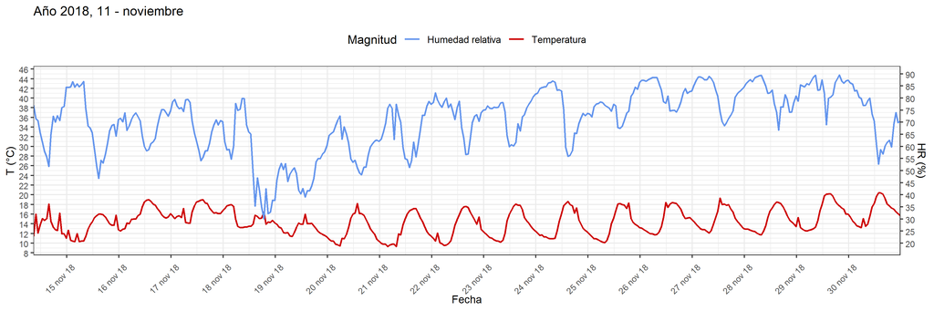

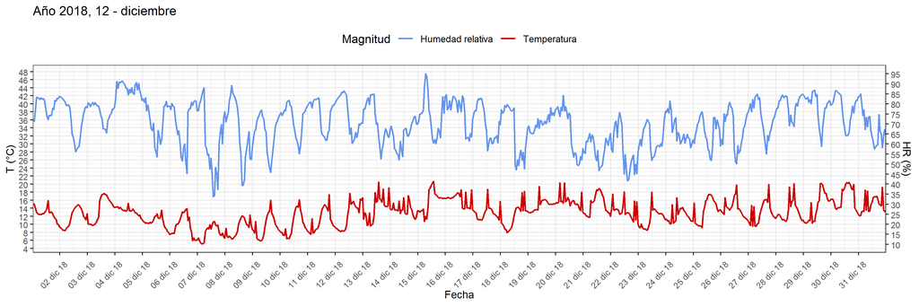

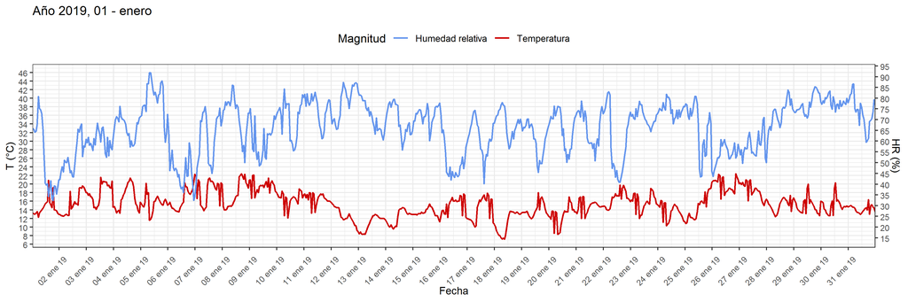

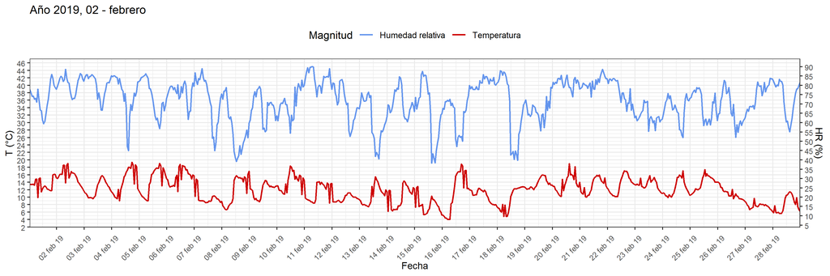

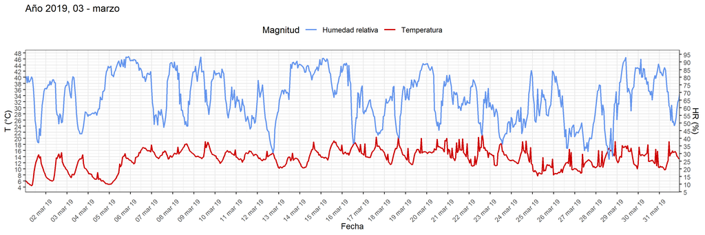

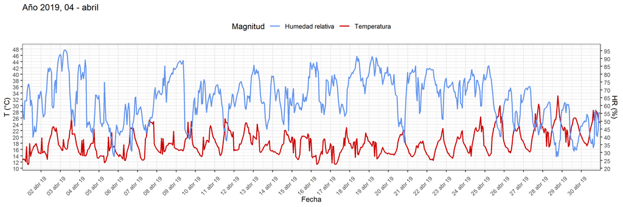

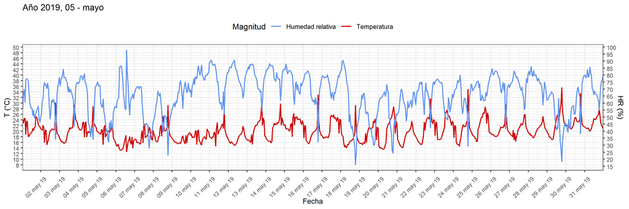

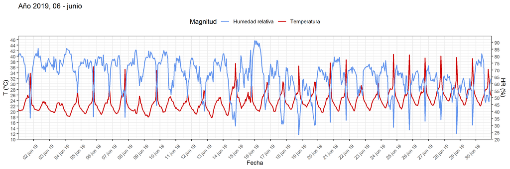

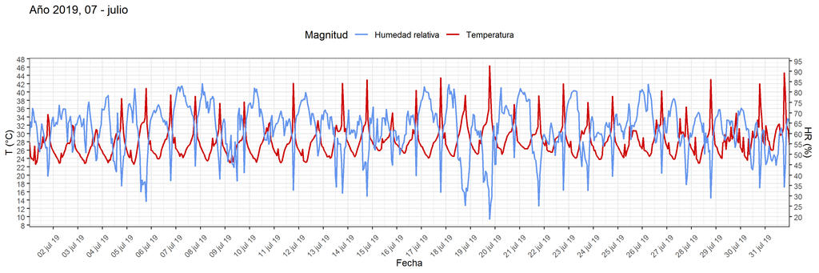

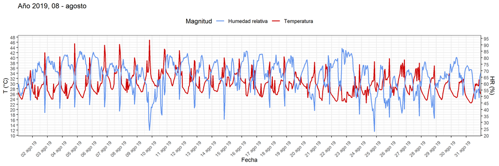

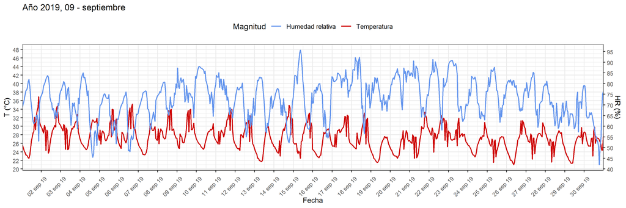

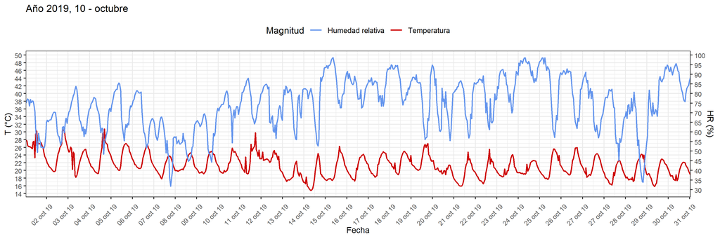

[3 more figures not shown]

#### Oscilaciones diarias y horarias de cada mes

##### Oscilación máxima diaria para cada mes

Tabla de oscilaciones diarias de Temperatura (ºC) y Humedad Relativa (%) según meses

| Mes | Nº Días | OD Media HR | OD Mediana HR | SD OD HR | OD Max HR | Fecha OD Max HR | OD Media T | OD Mediana T | SD OD T | OD Max T | Fecha OD Max T |
| --- | --- | --- | --- | --- | --- | --- | --- | --- | --- | --- | --- |
| 2018_11 | 17 | 26.3 | 24.3 | 8.9 | 49.8 | 18/11/2018 | 6.9 | 7.2 | 1.3 | 8.8 | 20/11/2018 |
| 2018_12 | 31 | 27.0 | 26.7 | 9.7 | 54.3 | 07/12/2018 | 8.0 | 8.0 | 1.8 | 10.9 | 13/12/2018 |
| 2019_01 | 31 | 25.6 | 25.0 | 8.9 | 48.5 | 01/01/2019 | 6.7 | 6.6 | 1.6 | 9.6 | 25/01/2019 |
| 2019_02 | 28 | 26.6 | 24.2 | 10.7 | 49.2 | 15/02/2019 | 7.0 | 6.9 | 2.5 | 14.9 | 16/02/2019 |
| 2019_03 | 31 | 33.0 | 33.6 | 10.4 | 52.7 | 16/03/2019 | 6.8 | 7.1 | 2.1 | 10.8 | 22/03/2019 |
| 2019_04 | 30 | 33.1 | 32.3 | 9.2 | 50.3 | 09/04/2019 | 9.9 | 9.4 | 2.8 | 16.3 | 28/04/2019 |
| 2019_05 | 31 | 37.0 | 37.0 | 12.2 | 74.4 | 18/05/2019 | 11.2 | 10.9 | 4.2 | 20.3 | 24/05/2019 |
| 2019_06 | 30 | 37.1 | 39.8 | 10.1 | 52.4 | 14/06/2019 | 12.6 | 12.7 | 5.0 | 19.6 | 25/06/2019 |
| 2019_07 | 31 | 38.6 | 38.7 | 9.9 | 58.2 | 18/07/2019 | 14.5 | 14.8 | 3.8 | 21.3 | 19/07/2019 |
| 2019_08 | 31 | 37.3 | 39.3 | 8.0 | 51.3 | 24/08/2019 | 13.5 | 13.4 | 3.5 | 21.3 | 04/08/2019 |
| 2019_09 | 30 | 24.9 | 24.3 | 6.8 | 39.5 | 04/09/2019 | 8.5 | 8.2 | 1.9 | 14.4 | 01/09/2019 |
| 2019_10 | 31 | 28.7 | 28.1 | 7.8 | 47.0 | 29/10/2019 | 7.1 | 7.0 | 1.9 | 11.6 | 04/10/2019 |
| 2019_11 | 30 | 25.1 | 25.2 | 9.3 | 47.4 | 04/11/2019 | 8.0 | 7.7 | 2.0 | 11.3 | 18/11/2019 |
| 2019_12 | 31 | 26.5 | 25.7 | 11.0 | 55.7 | 14/12/2019 | 7.9 | 7.7 | 2.2 | 11.9 | 14/12/2019 |
| 2020_01 | 16 | 28.3 | 27.1 | 10.4 | 51.6 | 11/01/2020 | 8.2 | 8.6 | 2.5 | 12.1 | 07/01/2020 |

OD = Oscilación diaria  
SD = Desviación estándar

##### Oscilación máxima horaria para cada mes

Tabla de oscilaciones horarias de Temperatura (ºC) y Humedad Relativa (%) según meses

| Mes | Nº Días | OH Media HR | OH Mediana HR | SD OH HR | OH Max HR | Fecha y hora OH Max HR | OH Media T | OH Mediana T | SD OH T | OH Max T | Fecha y hora OH Max T |
| --- | --- | --- | --- | --- | --- | --- | --- | --- | --- | --- | --- |
| 2018_11 | 17 | 3.0 | 2.0 | 3.0 | 17.6 | 18/11/2018 - 05 | 0.7 | 0.5 | 0.7 | 4.6 | 14/11/2018 - 09 |
| 2018_12 | 31 | 3.3 | 2.5 | 3.5 | 30.7 | 06/12/2018 - 15 | 1.0 | 0.5 | 1.4 | 6.1 | 11/12/2018 - 19 |
| 2019_01 | 31 | 3.4 | 2.4 | 3.4 | 24.8 | 22/01/2019 - 06 | 1.0 | 0.5 | 1.4 | 6.4 | 30/01/2019 - 11 |
| 2019_02 | 28 | 3.2 | 2.3 | 3.4 | 29.3 | 18/02/2019 - 11 | 0.9 | 0.4 | 1.3 | 6.7 | 06/02/2019 - 10 |
| 2019_03 | 31 | 3.9 | 2.7 | 3.8 | 22.6 | 20/03/2019 - 08 | 0.9 | 0.4 | 1.2 | 6.2 | 31/03/2019 - 11 |
| 2019_04 | 30 | 4.1 | 2.8 | 4.3 | 38.2 | 04/04/2019 - 08 | 1.2 | 0.6 | 1.5 | 7.1 | 07/04/2019 - 20 |
| 2019_05 | 31 | 4.2 | 2.7 | 4.7 | 42.3 | 06/05/2019 - 13 | 1.4 | 0.6 | 1.8 | 11.4 | 16/05/2019 - 18 |
| 2019_06 | 30 | 4.3 | 2.6 | 4.9 | 34.0 | 15/06/2019 - 18 | 1.1 | 0.6 | 1.7 | 11.5 | 24/06/2019 - 18 |
| 2019_07 | 31 | 4.7 | 3.0 | 5.0 | 31.5 | 09/07/2019 - 12 | 1.4 | 0.7 | 2.0 | 13.4 | 31/07/2019 - 18 |
| 2019_08 | 31 | 4.4 | 2.6 | 5.2 | 33.2 | 21/08/2019 - 20 | 1.7 | 0.7 | 2.2 | 14.3 | 04/08/2019 - 19 |
| 2019_09 | 30 | 3.1 | 2.2 | 2.9 | 18.7 | 29/09/2019 - 16 | 1.2 | 0.6 | 1.4 | 6.7 | 18/09/2019 - 17 |
| 2019_10 | 31 | 3.1 | 2.1 | 3.1 | 21.3 | 20/10/2019 - 10 | 0.7 | 0.5 | 0.8 | 6.2 | 01/10/2019 - 11 |
| 2019_11 | 30 | 3.1 | 2.4 | 2.9 | 17.7 | 04/11/2019 - 21 | 1.1 | 0.5 | 1.5 | 6.4 | 14/11/2019 - 16 |
| 2019_12 | 31 | 2.9 | 2.0 | 3.4 | 40.1 | 17/12/2019 - 16 | 1.0 | 0.5 | 1.4 | 6.1 | 02/12/2019 - 04 |
| 2020_01 | 16 | 3.6 | 2.3 | 4.2 | 38.8 | 07/01/2020 - 20 | 1.1 | 0.6 | 1.4 | 6.0 | 05/01/2020 - 21 |

OH = Oscilación horaria  
SD = Desviación estándar

### Análisis estacional

#### Modelización de un día típico de cada estación

Promedio de valores horarios de los meses de enero, abril, julio y octubre.

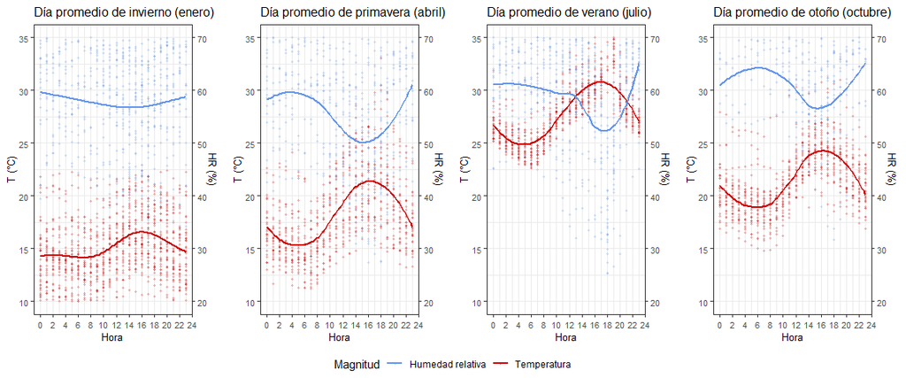